# Week 4: Data wrangling & tidying

Dani Cosme

2021-04-02

# resources

Here are a number of helpful resources to dig deeper into data wrangling and tidying using `tidyverse` packages:

**UO Bootcamp modules**

- [Introduction to the Tidyverse](https://uopsych-r-bootcamp-2020.netlify.app/post/04-intro-tidyverse/)
- [Importing Data & Project-oriented Workflows](https://uopsych-r-bootcamp-2020.netlify.app/post/05-importing-workflows/)
- [Data Wrangling With {dplyr}](https://uopsych-r-bootcamp-2020.netlify.app/post/07-dplyr/)
- [Data Tidying With {tidyr}](https://github.com/rstudio/cheatsheets/raw/master/data-import.pdf)

**Cheat sheets**

- [Data transformation with dplyr](https://github.com/rstudio/cheatsheets/raw/master/data-transformation.pdf)
- [Data tidying tidyr/readr](https://github.com/rstudio/cheatsheets/raw/master/data-transformation.pdf)
- [More useful cheat sheets!](https://www.rstudio.com/resources/cheatsheets/)

# load packages

```r
if (!require(pacman)) {
  install.packages('pacman')
}
pacman::p_load("tidyverse", "here", install = TRUE)
```

# load the data file

First, check your current working directory

```r
here()
```

```
## [1] "/Users/danicosme/Documents/code/cnlab/PLTV/pltv-seminar"
```

Modify the path as needed to where your `week4_data.csv` file is downloaded. Note, my path is a little different, but for you, it should be in the `data/` directory in the same folder as this script.

Import the csv file and assign it to the variable `data`

```r
data = read_csv(here("static", "labs", "data", "week4_data.csv"))
```

# check the data file

Check the names of the variables using `names()`

```r
names(data)
```

```
##   [1] "StartDate"             "EndDate"               "Status"
##   [4] "Progress"              "Duration (in seconds)" "Finished"
##   [7] "RecordedDate"          "ResponseId"            "DistributionChannel"
##  [10] "UserLanguage"          "Q151_First Click"      "Q151_Last Click"
##  [13] "Q151_Page Submit"      "Q151_Click Count"      "consent"
##  [16] "vote_registered"       "behavior_mailin"       "behavior_voting"
##  [19] "behavior_pollworker"   "attitude_1"            "attitude_2"
##  [22] "sn_injunctive"         "sn_descriptive"        "CE_attitudes_1"
##  [25] "CE_attitudes_2"        "CE_attitudes_3"        "CE_attitudes_4"
##  [28] "CE_attitudes_5"        "CE_attitudes_6"        "CE_attitudes_7"
##  [31] "CE_attitudes_8"        "CE_checklist_1"        "CE_checklist_2"
##  [34] "CE_checklist_3"        "CE_checklist_4"        "CE_checklist_5"
##  [37] "CE_checklist_6"        "CE_checklist_7"        "CE_checklist_8"
##  [40] "CE_checklist_9"        "CE_checklist_10"       "CE_checklist_11"
##  [43] "CE_checklist_12"       "CE_checklist_13"       "CE_checklist_14"
```

[output cut: 24 more lines]

Check the data types using `glimpse()`

```r
glimpse(data)
```

```
## Rows: 183
## Columns: 115
## $ StartDate               <chr> "Start Date", "{\"ImportId\":\"startDate\",\"t…
## $ EndDate                 <chr> "End Date", "{\"ImportId\":\"endDate\",\"timeZ…
## $ Status                  <chr> "Response Type", "{\"ImportId\":\"status\"}", …
## $ Progress                <chr> "Progress", "{\"ImportId\":\"progress\"}", "10…
## $ `Duration (in seconds)` <chr> "Duration (in seconds)", "{\"ImportId\":\"dura…
## $ Finished                <chr> "Finished", "{\"ImportId\":\"finished\"}", "1"…
## $ RecordedDate            <chr> "Recorded Date", "{\"ImportId\":\"recordedDate…
## $ ResponseId              <chr> "Response ID", "{\"ImportId\":\"_recordId\"}",…
## $ DistributionChannel     <chr> "Distribution Channel", "{\"ImportId\":\"distr…
## $ UserLanguage            <chr> "User Language", "{\"ImportId\":\"userLanguage…
## $ `Q151_First Click`      <chr> "Timing - First Click", "{\"ImportId\":\"QID14…
## $ `Q151_Last Click`       <chr> "Timing - Last Click", "{\"ImportId\":\"QID149…
## $ `Q151_Page Submit`      <chr> "Timing - Page Submit", "{\"ImportId\":\"QID14…
```

[output cut: 102 more lines]

Check the number of rows and columns using `nrow()` and `ncol()`

```r
nrow(data)
```

```
## [1] 183
```

```r
ncol(data)
```

```
## [1] 115
```

Check the first 10 rows using `head()`

```r
head(data, n = 10)
```

| StartDate | EndDate | Status | Progress | Duration (in seconds) | Finished | RecordedDate | ResponseId | DistributionChannel | UserLanguage | Q151_First Click | Q151_Last Click | Q151_Page Submit | Q151_Click Count | consent | vote_registered | behavior_mailin | behavior_voting | behavior_pollworker | attitude_1 | attitude_2 | sn_injunctive | sn_descriptive | CE_attitudes_1 | CE_attitudes_2 | CE_attitudes_3 | CE_attitudes_4 | CE_attitudes_5 | CE_attitudes_6 | CE_attitudes_7 | … |
| --- | --- | --- | --- | --- | --- | --- | --- | --- | --- | --- | --- | --- | --- | --- | --- | --- | --- | --- | --- | --- | --- | --- | --- | --- | --- | --- | --- | --- | --- | --- |
| Start Date | End Date | Response Type | Progress | Duration (in seconds) | Finished | Recorded Date | Response ID | Distribution Channel | User Language | Timing - First Click | Timing - Last Click | Timing - Page Submit | Timing - Click Count | By clicking the "I agree" button below, you are agreeing to take part in the second part of this research study. | Did you register to vote in the 2020 presidential election? | Did you request a mail-in ballot to vote in the 2020 presidential election. | Did you vote in the 2020 presidential election? | Did you serve as a poll worker for the 2020 presidential election. | My voting in the 2020 presidential election was - a bad thing:a good thing | My voting in the 2020 presidential election was - an unpleasant experience:a pleasant experience | Most people who are important to me approve of my voting in the 2020 presidential election. | Most people who are important to me voted in the 2020 presidential election. | To what extent do you agree or disagree with the following statements? - I feel responsible for my community. | To what extent do you agree or disagree with the following statements? - I believe I should make a difference in my community. | To what extent do you agree or disagree with the following statements? - I believe that I have a responsibility to help people who are less well off than myself. | To what extent do you agree or disagree with the following statements? - I am committed to serve in my community. | To what extent do you agree or disagree with the following statements? - I believe that all citizens have a responsibility to their community. | To what extent do you agree or disagree with the following statements? - I believe that it is important to be informed about community issues. | To what extent do you agree or disagree with the following statements? - I believe that it is important to volunteer. | … |
| {"ImportId":"startDate","timeZone":"America/New_York"} | {"ImportId":"endDate","timeZone":"America/New_York"} | {"ImportId":"status"} | {"ImportId":"progress"} | {"ImportId":"duration"} | {"ImportId":"finished"} | {"ImportId":"recordedDate","timeZone":"America/New_York"} | {"ImportId":"_recordId"} | {"ImportId":"distributionChannel"} | {"ImportId":"userLanguage"} | {"ImportId":"QID149_FIRST_CLICK"} | {"ImportId":"QID149_LAST_CLICK"} | {"ImportId":"QID149_PAGE_SUBMIT"} | {"ImportId":"QID149_CLICK_COUNT"} | {"ImportId":"QID119"} | {"ImportId":"QID155"} | {"ImportId":"QID21"} | {"ImportId":"QID153"} | {"ImportId":"QID23"} | {"ImportId":"QID1_1"} | {"ImportId":"QID1_2"} | {"ImportId":"QID2"} | {"ImportId":"QID3"} | {"ImportId":"QID8_1"} | {"ImportId":"QID8_2"} | {"ImportId":"QID8_3"} | {"ImportId":"QID8_4"} | {"ImportId":"QID8_5"} | {"ImportId":"QID8_6"} | {"ImportId":"QID8_7"} | … |
| 10/26/20 10:13 | 10/26/20 10:14 | 1 | 100 | 69 | 1 | 10/26/20 10:15 | R_2uwVznQoeyeldF8 | preview | EN | 0 | 0 | 0.203 | 0 | 1 | NA | NA | 1 | NA | NA | NA | NA | NA | NA | NA | NA | NA | NA | NA | NA | … |
| 10/26/20 10:15 | 10/26/20 10:16 | 1 | 100 | 48 | 1 | 10/26/20 10:16 | R_2WYi7waUVb1odOy | preview | EN | 0 | 0 | 0.206 | 0 | 1 | NA | NA | 1 | NA | NA | NA | NA | NA | NA | NA | NA | NA | NA | NA | NA | … |
| 10/26/20 11:14 | 10/26/20 11:15 | 1 | 100 | 80 | 1 | 10/26/20 11:15 | R_yVnwIpSwiLhnLvX | preview | EN | 0 | 0 | 0.204 | 0 | 1 | NA | NA | 2 | NA | NA | NA | NA | NA | NA | NA | NA | NA | NA | NA | NA | … |
| 10/23/20 17:11 | 10/23/20 17:11 | 0 | 4 | 5 | 0 | 10/30/20 17:11 | R_3mktpbuojRuzKMF | anonymous | EN | 0 | 0 | 0.105 | 0 | NA | NA | NA | NA | NA | NA | NA | NA | NA | NA | NA | NA | NA | NA | NA | NA | … |
| 10/23/20 17:08 | 10/23/20 17:23 | 0 | 4 | 911 | 0 | 10/30/20 17:23 | R_1LO6jF83Nuo1iFl | anonymous | EN | 0 | 0 | 0.205 | 0 | NA | NA | NA | NA | NA | NA | NA | NA | NA | NA | NA | NA | NA | NA | NA | NA | … |
| 11/2/20 12:34 | 11/2/20 12:43 | 0 | 100 | 547 | 1 | 11/2/20 12:43 | R_3Gp961UT9BNkxCF | anonymous | EN | 0 | 0 | 0.21 | 0 | 1 | 1 | 1 | 1 | 2 | 7 | 7 | 7 | 7 | 6 | 7 | 6 | 6 | 6 | 6 | 7 | … |
| 11/2/20 14:00 | 11/2/20 14:08 | 0 | 100 | 437 | 1 | 11/2/20 14:08 | R_2abjLOinVp5zcvo | anonymous | EN | 0 | 0 | 0.21 | 0 | 1 | 1 | 2 | 2 | 2 | NA | NA | NA | 6 | 3 | 5 | 5 | 3 | 5 | 4 | 4 | … |
| 11/2/20 14:05 | 11/2/20 14:10 | 0 | 100 | 300 | 1 | 11/2/20 14:10 | R_3lun7JrZiOjYkgo | anonymous | EN | 0 | 0 | 0.103 | 0 | 1 | 1 | 1 | 1 | 2 | 7 | 5 | 7 | 6 | 5 | 5 | 6 | 6 | 6 | 6 | 6 | … |

View the dataframe using `View()`

```r
View(data)
```

# rename columns

Rename the following columns using `rename()`:

The `%>%` operator is called a pipe. You can think of it as meaning “and then”. So, we’re going to take the `data` variable **and then** rename three columns

```r
# rename variables
data_renamed = data %>%
  rename("political_expression_1" = `pol_expr&contcreat_1`,
         "political_expression_2" = `pol_expr&contcreat_2`,
         "political_expression_3" = `pol_expr&contcreat_3`)

# check the names
names(data_renamed)
```

```
##   [1] "StartDate"              "EndDate"                "Status"
##   [4] "Progress"               "Duration (in seconds)"  "Finished"
##   [7] "RecordedDate"           "ResponseId"             "DistributionChannel"
##  [10] "UserLanguage"           "Q151_First Click"       "Q151_Last Click"
##  [13] "Q151_Page Submit"       "Q151_Click Count"       "consent"
##  [16] "vote_registered"        "behavior_mailin"        "behavior_voting"
##  [19] "behavior_pollworker"    "attitude_1"             "attitude_2"
##  [22] "sn_injunctive"          "sn_descriptive"         "CE_attitudes_1"
##  [25] "CE_attitudes_2"         "CE_attitudes_3"         "CE_attitudes_4"
##  [28] "CE_attitudes_5"         "CE_attitudes_6"         "CE_attitudes_7"
##  [31] "CE_attitudes_8"         "CE_checklist_1"         "CE_checklist_2"
##  [34] "CE_checklist_3"         "CE_checklist_4"         "CE_checklist_5"
##  [37] "CE_checklist_6"         "CE_checklist_7"         "CE_checklist_8"
##  [40] "CE_checklist_9"         "CE_checklist_10"        "CE_checklist_11"
##  [43] "CE_checklist_12"        "CE_checklist_13"        "CE_checklist_14"
```

[output cut: 24 more lines]

```r
# select only names that start with "political" using the grepl() function
# grepl() uses regular expressions to match patterns

names(data_renamed)[grepl("political", names(data_renamed))]
```

```
## [1] "political_expression_1" "political_expression_2" "political_expression_3"
```

# filter out responses

Filter out the following responses using `filter()`:

- Remove test responses (`DistributionChannel == "preview"`)
- Incomplete responses (`Finished == 0`)
- Participants who didn’t consent (`consent == 0`)

```r
# filter
data_filtered = data_renamed %>%
  filter(!DistributionChannel == "preview") %>%
  filter(Finished == 1 & consent == 1)

# check the number of rows
nrow(data_filtered)
```

```
## [1] 166
```

# recode responses

The variable `CE_voting` had a response option outside of the 1-4 scale range, and this was coded as `99` to flag people who were not eligible to vote in previous election.

We want to recode that as missing data using `NA`.

`ifelse()` is a logical statement that means “if test is true, do X; otherwise (i.e. if test is false) do Y”

```r
# check unique response values
unique(data_filtered$CE_voting)
```

```
## [1] "99" "2"  "3"  "4"  "1"
```

```r
# recode
data_recoded = data_filtered %>%
  mutate(CE_voting = ifelse(test = CE_voting == 99,
                            yes = NA,
                            no = CE_voting))

# check unique response values again
unique(data_recoded$CE_voting)
```

```
## [1] NA  "2" "3" "4" "1"
```

```r
mean(as.numeric(data_filtered$CE_voting), na.rm = TRUE)
```

```
## [1] 45.45783
```

# select a subset of columns

Select the following columns using `select()`, and `contains()` and `starts_with()` to match patterns of the column names:

- `ResponseId`
- `behavior_voting`
- all columns that start with `CE_attitudes`
- all columns that contain `checklist`

```r
data_select = data_recoded %>%
  select(ResponseId, behavior_voting, starts_with("CE_attitudes"), contains("checklist"))

data_select
```

| ResponseId | behavior_voting | CE_attitudes_1 | CE_attitudes_2 | CE_attitudes_3 | CE_attitudes_4 | CE_attitudes_5 | CE_attitudes_6 | CE_attitudes_7 | CE_attitudes_8 | CE_checklist_1 | CE_checklist_2 | CE_checklist_3 | CE_checklist_4 | CE_checklist_5 | CE_checklist_6 | CE_checklist_7 | CE_checklist_8 | CE_checklist_9 | CE_checklist_10 | CE_checklist_11 | CE_checklist_12 | CE_checklist_13 | CE_checklist_14 | CE_checklist_15 | CE_checklist_16 | CE_checklist_17 |
| --- | --- | --- | --- | --- | --- | --- | --- | --- | --- | --- | --- | --- | --- | --- | --- | --- | --- | --- | --- | --- | --- | --- | --- | --- | --- | --- |
| R_3Gp961UT9BNkxCF | 1 | 6 | 7 | 6 | 6 | 6 | 6 | 7 | 7 | 1 | 1 | 2 | 2 | 1 | 2 | 2 | 2 | 2 | 2 | 2 | 2 | 2 | 1 | 2 | 2 | 2 |
| R_2abjLOinVp5zcvo | 2 | 3 | 5 | 5 | 3 | 5 | 4 | 4 | 5 | 2 | 2 | 1 | 2 | 1 | 1 | 2 | 1 | 2 | 2 | 2 | 2 | 2 | 2 | 2 | 2 | 2 |
| R_3lun7JrZiOjYkgo | 1 | 5 | 5 | 6 | 6 | 6 | 6 | 6 | 6 | 2 | 2 | 1 | 2 | 2 | 1 | 1 | 2 | 2 | 2 | 2 | 2 | 2 | 1 | 1 | 1 | 2 |
| R_40VV5bSVDU5LZL3 | 2 | 5 | 6 | 5 | 5 | 5 | 7 | 6 | 6 | 2 | 1 | 2 | 2 | 2 | 1 | 2 | 2 | 2 | 2 | 2 | 2 | 2 | 2 | 2 | 2 | 2 |
| R_1mn6vlqCbDaVVNw | 2 | 3 | 7 | 7 | 7 | 5 | 7 | 7 | 7 | 1 | 1 | 2 | 2 | 1 | 2 | 2 | 2 | 2 | 2 | 2 | 2 | 2 | 2 | 2 | 2 | 2 |
| R_3qmQoXEqLFh7Kn1 | 1 | 7 | 7 | 7 | 7 | 7 | 5 | 7 | 7 | 1 | 1 | 1 | 2 | 2 | 2 | 2 | 2 | 2 | 2 | 2 | 2 | 2 | 2 | 2 | 2 | 2 |
| R_C9wzCa09R7kujVD | 1 | 5 | 6 | 6 | 4 | 6 | 6 | 6 | 5 | 1 | 2 | 1 | 2 | 2 | 1 | 2 | 2 | 2 | 2 | 2 | 2 | 2 | 1 | 2 | 2 | 2 |
| R_3JhnTdSOc1WYLQO | 1 | 5 | 5 | 6 | 5 | 5 | 6 | 6 | 6 | 2 | 2 | 1 | 2 | 2 | 1 | 2 | 1 | 2 | 2 | 2 | 2 | 2 | 2 | 2 | 2 | 2 |
| R_BJRHkQN8EEmZYxb | 1 | 4 | 6 | 6 | 6 | 6 | 6 | 6 | 6 | 1 | 1 | 2 | 2 | 2 | 1 | 2 | 2 | 2 | 2 | 2 | 2 | 2 | 1 | 1 | 2 | 2 |
| R_1Q57Htl3BkVeu8Z | 1 | 5 | 7 | 5 | 5 | 7 | 5 | 5 | 6 | 1 | 2 | 2 | 2 | 2 | 2 | 2 | 2 | 2 | 2 | 2 | 2 | 2 | 1 | 2 | 2 | 2 |

[output cut: 156 more lines]

# convert from wide to long format

To more easily wrangle the data for multiple columns at once, we’re going to convert from the wide to the long format using `pivot_longer()`.

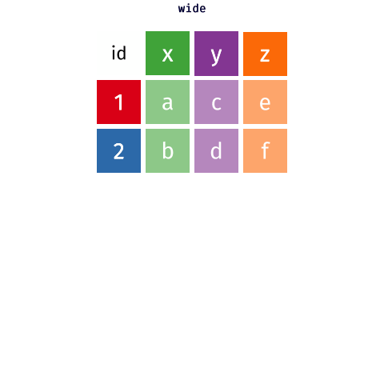

Do this for all variables except `ResponseId` and `behavior_voting` by specifying these columns with the `cols =` argument.

Let’s also rename the `name` column (the default) to `scale_name` using `names_to = "scale_name"`.

```r
data_long = data_select %>%
  pivot_longer(cols = -c(ResponseId, behavior_voting), names_to = "scale_name")

data_long
```

| ResponseId | behavior_voting | scale_name | value |
| --- | --- | --- | --- |
| R_3Gp961UT9BNkxCF | 1 | CE_attitudes_1 | 6 |
| R_3Gp961UT9BNkxCF | 1 | CE_attitudes_2 | 7 |
| R_3Gp961UT9BNkxCF | 1 | CE_attitudes_3 | 6 |
| R_3Gp961UT9BNkxCF | 1 | CE_attitudes_4 | 6 |
| R_3Gp961UT9BNkxCF | 1 | CE_attitudes_5 | 6 |
| R_3Gp961UT9BNkxCF | 1 | CE_attitudes_6 | 6 |
| R_3Gp961UT9BNkxCF | 1 | CE_attitudes_7 | 7 |
| R_3Gp961UT9BNkxCF | 1 | CE_attitudes_8 | 7 |
| R_3Gp961UT9BNkxCF | 1 | CE_checklist_1 | 1 |
| R_3Gp961UT9BNkxCF | 1 | CE_checklist_2 | 1 |

[output cut: 4140 more lines]

# extract item number from scale name

`scale_name` contains both the names of the scale (`CE_attitudes` or `CE_checklist`) as well as the item number.

Let’s use `extract()` to separate these components into two separate columns called `scale_name` and `item`.

The `col =` argument specifies the original column name, the `into =` argument is where we specify the names of the columns we want to create, and `regex =` specifies the regular expression pattern.

Regular expressions are SUPER helpful for wrangling and tidying. Learn more about them with [this cheat sheet](https://www.rstudio.com/wp-content/uploads/2016/09/RegExCheatsheet.pdf).

```r
data_scale = data_long %>%
  # extract the item number from scale
  extract(col = "scale_name", into = c("scale_name", "item"), regex = "(CE_attitudes|CE_checklist)_([0-9]+)") %>%
  # reorder variables using `select()`
  select(ResponseId, behavior_voting, scale_name, item, value)

data_scale
```

| ResponseId | behavior_voting | scale_name | item | value |
| --- | --- | --- | --- | --- |
| R_3Gp961UT9BNkxCF | 1 | CE_attitudes | 1 | 6 |
| R_3Gp961UT9BNkxCF | 1 | CE_attitudes | 2 | 7 |
| R_3Gp961UT9BNkxCF | 1 | CE_attitudes | 3 | 6 |
| R_3Gp961UT9BNkxCF | 1 | CE_attitudes | 4 | 6 |
| R_3Gp961UT9BNkxCF | 1 | CE_attitudes | 5 | 6 |
| R_3Gp961UT9BNkxCF | 1 | CE_attitudes | 6 | 6 |
| R_3Gp961UT9BNkxCF | 1 | CE_attitudes | 7 | 7 |
| R_3Gp961UT9BNkxCF | 1 | CE_attitudes | 8 | 7 |
| R_3Gp961UT9BNkxCF | 1 | CE_checklist | 1 | 1 |
| R_3Gp961UT9BNkxCF | 1 | CE_checklist | 2 | 1 |

[output cut: 4140 more lines]

# convert response values to numeric

Currently the responses in `value` are character strings. To use them as numbers, we need to convert the column to numeric values using `mutate()` and `as.numeric()`.

```r
# check variable type
typeof(data_scale$value)
```

```
## [1] "character"
```

```r
# convert to numeric
data_numeric = data_scale %>%
  mutate(value = as.numeric(value))

# check variable type
typeof(data_numeric$value)
```

```
## [1] "double"
```

# reverse score variables

Let’s say `CE_attitudes_1` is a reverse-scored item, so we want to flip the scale so it matches the other items. The scale ranges from 1 to 7, we’ll convert e.g. 1–>7 to 7–>1

We can do this using `mutate()` and `ifelse()`.

```r
# check range
range(data_select$CE_attitudes_1)
```

```
## [1] "2" "7"
```

```r
data_rev = data_numeric %>%
  mutate(value = ifelse(test = scale_name == "CE_attitudes" & item == 1,
                        yes = 8 - value, # subtract the value from scale max + 1
                        no = value))

data_rev
```

| ResponseId | behavior_voting | scale_name | item | value |
| --- | --- | --- | --- | --- |
| R_3Gp961UT9BNkxCF | 1 | CE_attitudes | 1 | 2 |
| R_3Gp961UT9BNkxCF | 1 | CE_attitudes | 2 | 7 |
| R_3Gp961UT9BNkxCF | 1 | CE_attitudes | 3 | 6 |
| R_3Gp961UT9BNkxCF | 1 | CE_attitudes | 4 | 6 |
| R_3Gp961UT9BNkxCF | 1 | CE_attitudes | 5 | 6 |
| R_3Gp961UT9BNkxCF | 1 | CE_attitudes | 6 | 6 |
| R_3Gp961UT9BNkxCF | 1 | CE_attitudes | 7 | 7 |
| R_3Gp961UT9BNkxCF | 1 | CE_attitudes | 8 | 7 |
| R_3Gp961UT9BNkxCF | 1 | CE_checklist | 1 | 1 |
| R_3Gp961UT9BNkxCF | 1 | CE_checklist | 2 | 1 |

[output cut: 4140 more lines]

# recode yes/no variables

`CE_checklist` is a series of yes/no questions that are currently coded as 1/2. We want to recode these to be 1/0 to make it easier to sum later on.

We’ll also recode `voting_behavior` from 1/2 to yes/no to make it clearer what these responses mean. Let’s try doing this using `recode()` instead of `ifelse()`.

```r
data_yn = data_rev %>%
  mutate(value = ifelse(test = scale_name == "CE_checklist" & value == 2,
                        yes = 0,
                        no = value),
         behavior_voting = recode(behavior_voting,
                                  "1" = "yes",
                                  "2" = "no"))

data_yn
```

| ResponseId | behavior_voting | scale_name | item | value |
| --- | --- | --- | --- | --- |
| R_3Gp961UT9BNkxCF | yes | CE_attitudes | 1 | 2 |
| R_3Gp961UT9BNkxCF | yes | CE_attitudes | 2 | 7 |
| R_3Gp961UT9BNkxCF | yes | CE_attitudes | 3 | 6 |
| R_3Gp961UT9BNkxCF | yes | CE_attitudes | 4 | 6 |
| R_3Gp961UT9BNkxCF | yes | CE_attitudes | 5 | 6 |
| R_3Gp961UT9BNkxCF | yes | CE_attitudes | 6 | 6 |
| R_3Gp961UT9BNkxCF | yes | CE_attitudes | 7 | 7 |
| R_3Gp961UT9BNkxCF | yes | CE_attitudes | 8 | 7 |
| R_3Gp961UT9BNkxCF | yes | CE_checklist | 1 | 1 |
| R_3Gp961UT9BNkxCF | yes | CE_checklist | 2 | 1 |

[output cut: 4140 more lines]

# summarize

Now that we’ve wrangled and tidyied our data, we can summarize it using `summarize()`.

## calculate mean civic engagement attitude across people

Because we just want to look at attitudes, we’ll first subset these items using `filter()`.

Then, using `group_by()` we’ll state that we want to calculate a mean across all items in the filtered `scale_name` column.

To calculate the mean of `value`, we’ll use `summarize()` and `mean()`. Because we want to ignore any missing data (specified as `NA` in the dataframe), we’ll also use the `na.rm = TRUE` argument in the `mean()` function.

```r
data_yn %>%
  filter(scale_name == "CE_attitudes") %>%
  group_by(scale_name) %>%
  summarize(mean = mean(value, na.rm = TRUE))
```

| scale_name | mean |
| --- | --- |
| CE_attitudes | 5.439759 |

```r
# this is what would happen if we didn't first filter out `CE_checklist`
data_yn %>%
  #filter(scale_name == "CE_attitudes") %>%
  group_by(scale_name) %>%
  summarize(mean = mean(value, na.rm = TRUE))
```

| scale_name | mean |
| --- | --- |
| CE_attitudes | 5.4397590 |
| CE_checklist | 0.2335223 |

## calculate mean and SD civic engagement attitude by voting behavior

This time, let’s use `group_by()` to calculate means and standard deviations of the civic engagement attitudes separately for people who voted and didn’t vote, specified in `behavior_voting`.

```r
data_yn %>%
  filter(scale_name == "CE_attitudes") %>%
  group_by(scale_name, behavior_voting) %>%
  summarize(mean = mean(value, na.rm = TRUE),
            sd = sd(value, na.rm = TRUE))
```

| scale_name | behavior_voting | mean | sd |
| --- | --- | --- | --- |
| CE_attitudes | no | 5.033333 | 1.068521 |
| CE_attitudes | yes | 5.480132 | 1.574318 |

## calculate means and sums per person

This time, let’s calculate these stats for each person separately rather than across all data points using `ResponseId` as a grouping factor.

```r
data_yn %>%
  group_by(ResponseId, scale_name) %>%
  summarize(mean = mean(value, na.rm = TRUE),
            sum = sum(value, na.rm = TRUE))
```

| ResponseId | scale_name | mean | sum |
| --- | --- | --- | --- |
| R_02MPrjbLPyLptIJ | CE_attitudes | 5.75000000 | 46 |
| R_02MPrjbLPyLptIJ | CE_checklist | 0.17647059 | 3 |
| R_0ohtUgJUvg3gQ93 | CE_attitudes | 6.25000000 | 50 |
| R_0ohtUgJUvg3gQ93 | CE_checklist | 0.05882353 | 1 |
| R_11cHQUDaGKsfAih | CE_attitudes | 6.50000000 | 52 |
| R_11cHQUDaGKsfAih | CE_checklist | 0.17647059 | 3 |
| R_1BPzOzjVzs32slr | CE_attitudes | 6.25000000 | 50 |
| R_1BPzOzjVzs32slr | CE_checklist | 0.29411765 | 5 |
| R_1Ca691FXZ6DOCpJ | CE_attitudes | 5.75000000 | 46 |
| R_1Ca691FXZ6DOCpJ | CE_checklist | 0.17647059 | 3 |

[output cut: 322 more lines]

# assignment

Now it’s your turn to apply what you’ve learned.

## select

Select the following subset of columns from `data_recoded`:

- `ResponseId`
- `vote_registered`
- variables that contain `behavior`
- variables that start with `attitude` but not those that start with `CE_attitudes`

Assign this to `assignment_data`

```r
assignment_data = data_recoded %>%
  select()
```

## convert to long format

Assign this to `assignment_data1`

```r
assignment_data1 = assignment_data %>%
  pivot_longer()
```

## recode

Recode the values in `value` as follows: * 1 = “yes” * 2 = "no

Assign this to `assignment_data2`

```r
assignment_data2 = assignment_data1 %>%
  mutate()
```

## convert from long to wide format

Use `pivot_wider()` to go from the long to the wide format. Here, we don’t need to specify any arguments. Just use `%>% pivot_wider()`.

Assign this to `assignment_data3`

```r
assignment_data3 = assignment_data2 %>%
  pivot_wider()
```

## filter

From `assignment_data3`, filter only people who reported being registered to vote (`vote_registered`).

Assign this to `assignment_data4`.

## convert to numeric

Convert `attitude_1` to numeric.

Assign this to `assignment_data5`.

## combine steps

Instead of doing each step separately and assigning them to new variables each time, use `%>%` to link the steps together.

Assign this to `assignment_combined`

## summarize

From `assignment_combined`, calculate the mean of `attitude_1` for yes and no responses to `behavior_mailin` separately using `group_by()` and `summarize()`.

When using the `mean()` function, include `na.rm = TRUE` to ignore missing values.

This time, do the same thing but with `mutate()` instead of `summarize()`. What’s different?